# Homework 3

Rong Ma

Nov 2 2015

# Revisiting HW4

```r
library(ggplot2)
library(gridExtra)
library(plyr)
library(dplyr)
library(tidyr)
gap <- read.delim("http://tiny.cc/gapminder", sep="\t")
```

Still we define a function gdprate, from which we can compute the relative increasing rate of GDP per Capita for each country (which is computed by letting $y_n=\frac{x_{n+1}−x_n}{x_n}$, for all n, where $x_{n+1}$ and $x_n$ are two consecutive records of GDP per Capita for the same country, and $y_n$ is the relative increasing rate from the nth value to the (n+1)th value of GDP per Capita).

```r
gdp.rate <- function(x, year = 12){
  stopifnot(is.data.frame(x))
  stopifnot(is.numeric(x$gdpPercap))
  rate <- x %>% mutate(rate = (gdpPercap - lag(gdpPercap))/lag(gdpPercap)) %>% select(rate)
  return(rate[2:year,1])
}
```

From the above function, we can find the maximum rate and minimum increasing rate of GDP per Cap for each country during all times.

```r
gdp.rate.data <- ddply(gap, ~country, gdp.rate)
years <- gap %>% select(year) %>% unique()
year.index <- paste0(years[1:11,1], rep("/",11),years[2:12,1])
names(gdp.rate.data)[-1] <- year.index
max.rate <- gdp.rate.data %>% select(2:dim(years)[1]) %>% apply(1,max)
min.rate <- gdp.rate.data %>% select(2:dim(years)[1]) %>% apply(1,min)
continent <- (gap %>% select(country,continent) %>% unique())[,2]
extreme.rate.data <- gdp.rate.data %>% mutate(max.rate,min.rate,continent) %>% select(country, continent, max.rate, min.rate)
knitr::kable(head(extreme.rate.data))
```

| country | continent | max.rate | min.rate |
| --- | --- | --- | --- |
| Afghanistan | Asia | 0.3410412 | -0.2382162 |
| Albania | Europe | 0.4419458 | -0.3320452 |
| Algeria | Africa | 0.2881658 | -0.1536705 |
| Angola | Africa | 0.7297996 | -0.4503035 |
| Argentina | Americas | 0.4525917 | -0.1978285 |
| Australia | Oceania | 0.1889871 | 0.0623322 |

We draw a plot of those maximum and minimum values as follows.

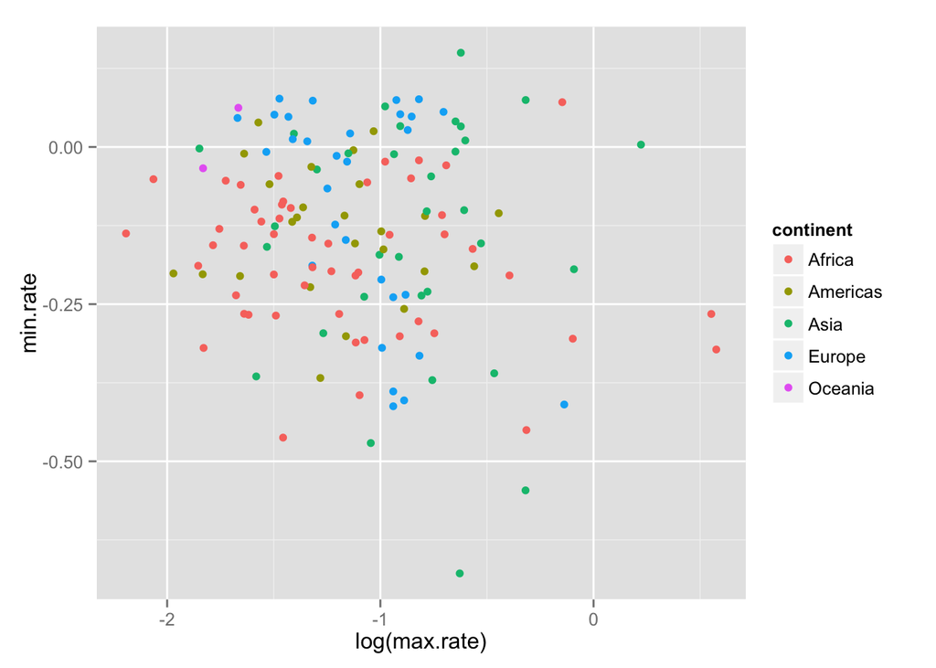

```r
p <- ggplot(extreme.rate.data,aes(log(max.rate),min.rate))
p + geom_point(aes(colour = continent))
```

This plot shows the general pattern of the relation between maximum and minimum increasing rate of gdpPercap for all countries.

# Factor Management

For the above derived data.frame `extreme.rate.data`, we first remove the observations associated with the continent of Oceania. We can see the effect of `droplevels()` as following.

```r
new.extreme.rate.data <- extreme.rate.data %>% filter(continent != "Oceania")
str(new.extreme.rate.data) #BEFORE droplevels()
```

```
## 'data.frame':    140 obs. of  4 variables:
##  $ country  : Factor w/ 142 levels "Afghanistan",..: 1 2 3 4 5 7 8 9 10 11 ...
##  $ continent: Factor w/ 5 levels "Africa","Americas",..: 3 4 1 1 2 4 3 3 4 1 ...
##  $ max.rate : num  0.341 0.442 0.288 0.73 0.453 ...
##  $ min.rate : num  -0.238 -0.332 -0.154 -0.45 -0.198 ...
```

```r
new.extreme.rate.data <- new.extreme.rate.data %>% droplevels()
str(new.extreme.rate.data) #AFTER droplevels()
```

```
## 'data.frame':    140 obs. of  4 variables:
##  $ country  : Factor w/ 140 levels "Afghanistan",..: 1 2 3 4 5 6 7 8 9 10 ...
##  $ continent: Factor w/ 4 levels "Africa","Americas",..: 3 4 1 1 2 4 3 3 4 1 ...
##  $ max.rate : num  0.341 0.442 0.288 0.73 0.453 ...
##  $ min.rate : num  -0.238 -0.332 -0.154 -0.45 -0.198 ...
```

Next we `reorder` the levels of continent in terms of the max.rate in ascending order, instead of the default alphabetic order.

```r
order.rate.data <- new.extreme.rate.data %>% mutate(continent = reorder(continent, max.rate))
data.frame(BEFORE = levels(new.extreme.rate.data$continent), AFTER = levels(order.rate.data$continent))
```

```
##     BEFORE    AFTER
## 1   Africa Americas
## 2 Americas   Europe
## 3     Asia   Africa
## 4   Europe     Asia
```

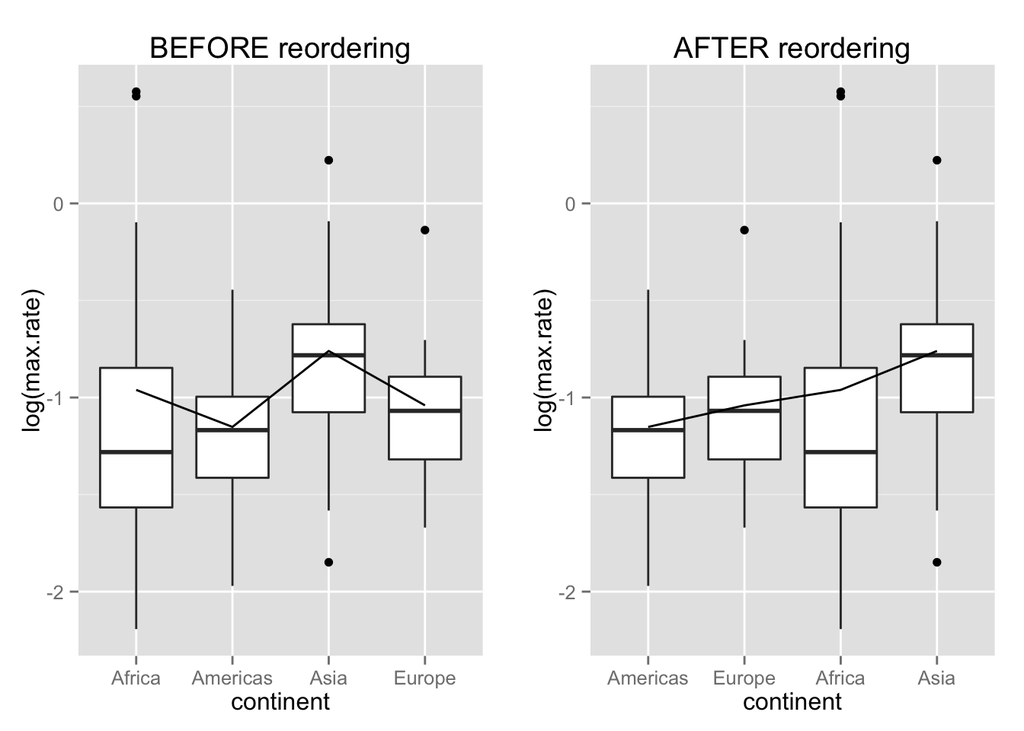

```r
means.continent <- (order.rate.data %>% group_by(continent) %>% summarize_each(funs(mean), max.rate))
p <- ggplot(new.extreme.rate.data, aes(x = continent, y = log(max.rate)))
plot1 <- p + geom_boxplot() + geom_line(data = means.continent, aes(x = continent, y = log(max.rate), group=1)) + labs(title = "BEFORE reordering")
p <- ggplot(order.rate.data, aes(x = continent, y = log(max.rate)))
plot2 <- p + geom_boxplot() + geom_line(data = means.continent, aes(x = continent, y = log(max.rate), group=1)) + labs(title = "AFTER reordering")
grid.arrange(plot1, plot2, ncol=2, nrow =1)
```

On the other hand, since `arrange` only reorder the observations(rows) based on a variable in descending or ascending order, it doesn’t change the order of the levels and has no effect on the plot as above.

# Visualization Design

We revise one of the plot we drew before.

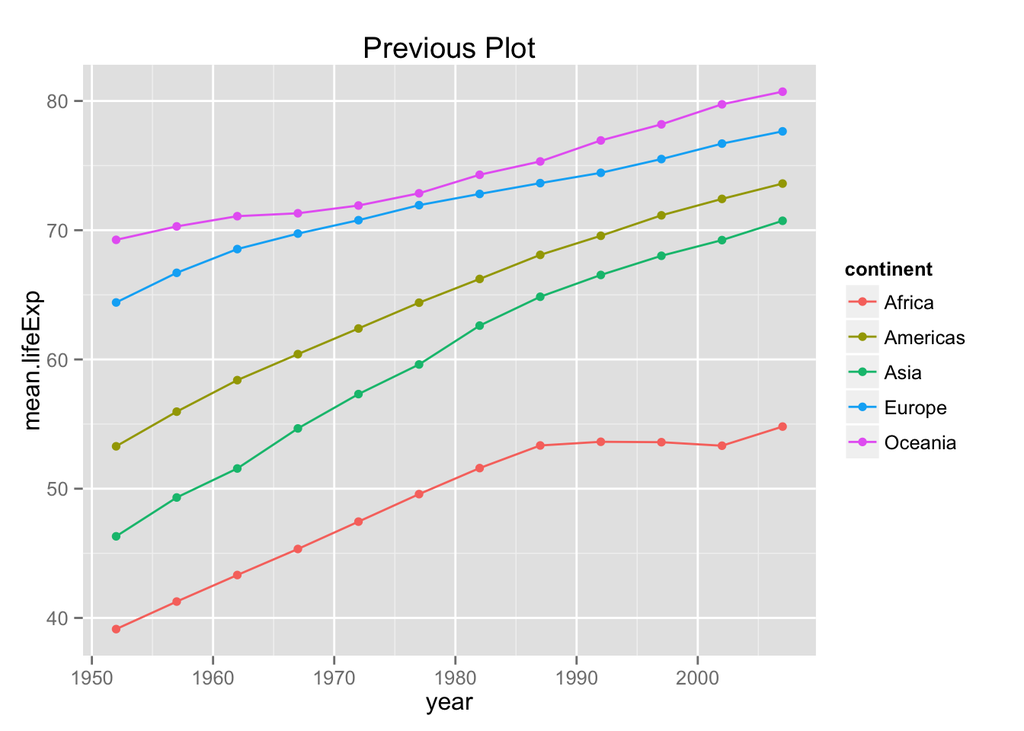

```r
continent.lifeExp.time <- gap %>% group_by(continent, add = FALSE) %>% group_by(continent, year, add = FALSE) %>% summarise(mean.lifeExp = mean(lifeExp), mean.pop = mean(pop))
p = ggplot(continent.lifeExp.time, aes(x = year, y = mean.lifeExp, color = continent))
p + geom_point() + geom_line() + labs(title = "Previous Plot")
```

We will: (1) reorder the levels of continent in terms of the mean.lifeExp; (2) add size to each point indicating the population; (3) drop the level Oceania due to its small size.

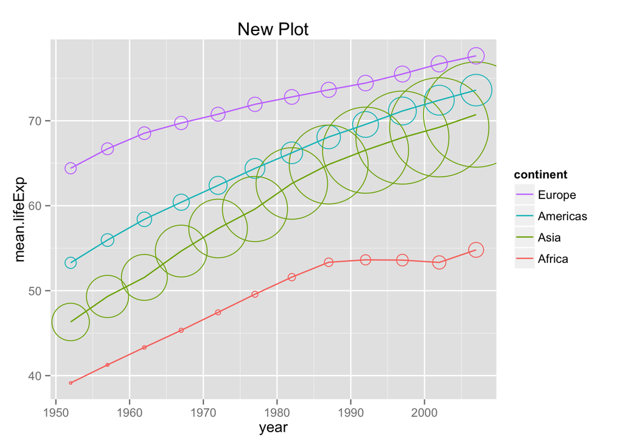

```r
new.plot <- function(data, pch = 21, show_guide = FALSE, range = c(1,40), drop = "Oceania"){
  p <- ggplot(as.data.frame(data) %>% mutate(continent = reorder(continent, mean.lifeExp)) %>% filter(continent != drop) %>% droplevels(), aes(x = year, y = mean.lifeExp, color = continent))
  p + geom_point(aes(size = mean.pop), pch=pch, show_guide = show_guide) + scale_size_continuous(range=range) + geom_line(aes(order = desc(continent))) + labs(title = "New Plot") + guides(color = guide_legend(reverse = TRUE))
}
new.plot(continent.lifeExp.time)
```